# MGTA 453 2019 - Assignment #3

Shihan Wang

# [1]

In Chapter 4 of the book, solve exercises: 4.2 and 4.18.

Answer these in R (feel free to solve on paper first if you’d like) in the folder’s `chapter_4_answers.Rmd` file.

# [2] Insurance Fraud

*Submission requirement:* This must all be submitted as one document, either a knitted HTML report from Radiant, or one knitted .Rmd file (along with pushing the raw Radiant state file or .Rmd file itself). The hints below correspond to Radiant, but you can also use R to perform the analysis.

(Tip: Book problem 3.20 from last week is an example that studies the distribution of a difference in random variables (or in other words, a difference between two sample means).)

== == ==

RadySafe Insurance company has recently come under increased pressure to improve its operation. Unfortunately, the investment side of its business has not been performing well, and management expects better operating income performance. One of their greatest concerns has been fraudulent claims.

Even worse, the company’s business analytics specialist was recently poached by one of its competitors who offered her quite a lucrative salary/benefits package. She relocated and started with them on January 1, 2009. The company realizes it cannot replace such a valuable human resource in a short amount of time, and has decided to contract you to help provide guidance on some key decisions.

It is Monday, January 5th, 2009, and RadySafe Insurance is eagerly awaiting your recommendations. As part of your contract, you have been given access to a random sample of 4,415 of their claims data from last year. This can be found in the file: `insurance.rds`.

### Question 1

*Should RadySafe Insurance raise premiums in 2009?*

Under RadySafe Insurance policy guidelines, a policy premium increase is merited if the average claim amount has increased by at least 5% over the previous year. The accounting department has reported that the average claim amount in 2007 was $63,500.

Note: The `claim_amount` variable in the dataset is reported in $1,000’s of dollars.

Make sure to clearly describe your null and alternative hypotheses. Would you order a reevaluation of the policy premiums based on the available data? Why or why not?

```r
library(radiant)
insurance <- readRDS('insurance.rds')
result <- single_mean(
  insurance,
  var = "claim_amount",
  comp_value = 63.5*(1.05),
  alternative = "great"
)
summary(result)
```

```
## Single mean test
## Data      : insurance
## Variable  : claim_amount
## Confidence: 0.95
## Null hyp. : the mean of claim_amount = 66.675
## Alt. hyp. : the mean of claim_amount is NA 66.675
##
##    mean      sd n_obs n_missing
##  73.011 144.401 4,415         0
##
##   diff    se t.value p.value   df   2.5% 97.5%
##  6.336 2.173   2.915   0.002 4414 69.436   Inf **
##
## Signif. codes:  0 '***' 0.001 '**' 0.01 '*' 0.05 '.' 0.1 ' ' 1
```

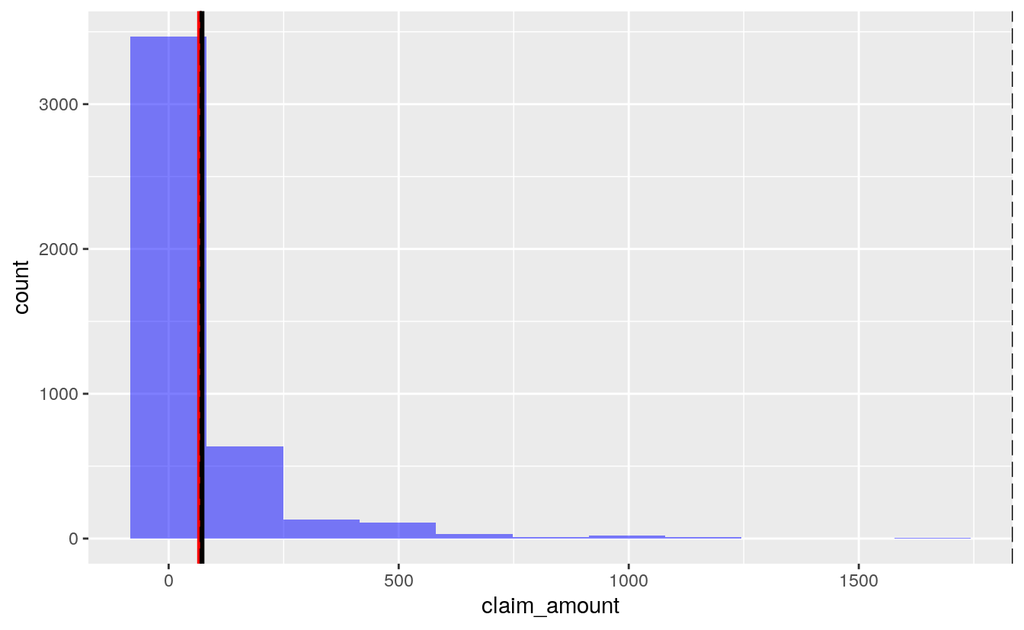

```r
plot(result, plots = "hist", custom = FALSE)
```

### Question 2

*Should RadySafe Insurance charge different demographic groups different premiums?*

RadySafe would like to revisit how their current premiums take into account gender and workforce status. If different demographic groups exhibit different claims behavior, perhaps they should be charged different premiums. For instance, if men tend to file larger and more frequent claims than women, perhaps they should also pay a higher policy premium to cover the additional risk. RadySafe would like you to examine the claims data provided to you to assess the following questions:

Do men claim higher amounts on their policy?  
*Hint: Make use of the `gender` variable to differentiate male and female customers*

H0: the average claim amount for man is equal to the average claim amount for woman. Ha: the average claim amount for man is higher than the average claim amount for woman. p value is 0.291. We do not reject the null hypothesis using a significance level of 0.05 and can’t conclude men claim higher amounts on their policy.

```r
result1 <- compare_means(
  insurance,
  var1 = "gender",
  var2 = "claim_amount",
  alternative = "greater"
)
summary(result1, show = FALSE)
```

```
## Pairwise mean comparisons (t-test)
## Data      : insurance
## Variables : gender, claim_amount
## Samples   : independent
## Confidence: 0.95
## Adjustment: None
##
##  gender   mean     n      sd    se    me
##    Male 74.229 2,175 147.858 3.170 6.217
##  Female 71.828 2,240 140.987 2.979 5.842
##
##  Null hyp.       Alt. hyp.       diff  p.value
##  Male = Female   Male > Female   2.401 0.291
##
## Signif. codes:  0 '***' 0.001 '**' 0.01 '*' 0.05 '.' 0.1 ' ' 1
```

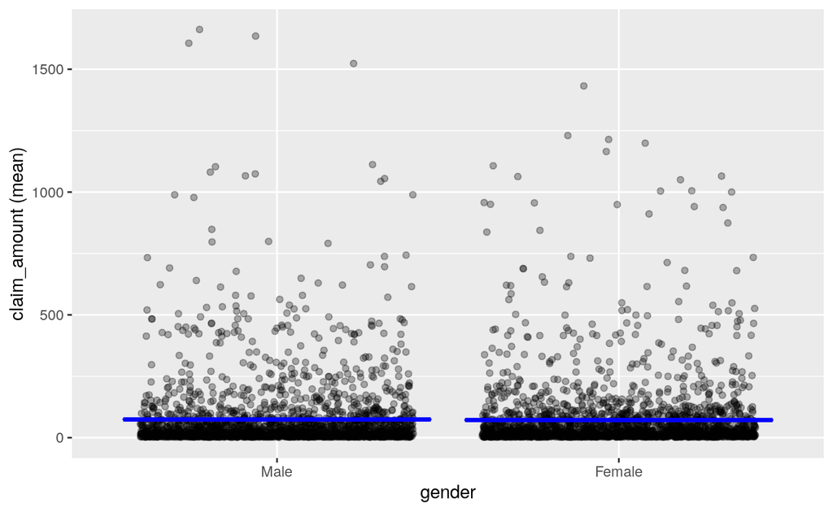

```r
plot(result1, plots = "scatter", custom = FALSE)
```

Do retirees claim lower amounts on their policy?  
*Hint: Similarly, make use of the `retire` variable.*

HO: the average claim amount for retirees is equal to the average claim amount for non-retirees. Ha: the average claim amount for retirees is less than the average claim amount for non-retirees. p value is <0.001. We reject the null hypothesis using a significance level of 0.05 and conclude retirees claim lower amounts on their policy.

```r
result2 <- compare_means(
  insurance,
  var1 = "retire",
  var2 = "claim_amount",
  alternative = "less"
)
summary(result2, show = FALSE)
```

```
## Pairwise mean comparisons (t-test)
## Data      : insurance
## Variables : retire, claim_amount
## Samples   : independent
## Confidence: 0.95
## Adjustment: None
##
##  retire   mean     n      sd    se    me
##     Yes 37.313   574  60.529 2.526 4.962
##      No 78.346 3,841 152.325 2.458 4.819
##
##  Null hyp.  Alt. hyp.  diff    p.value
##  Yes = No   Yes < No   -41.032 < .001  ***
##
## Signif. codes:  0 '***' 0.001 '**' 0.01 '*' 0.05 '.' 0.1 ' ' 1
```

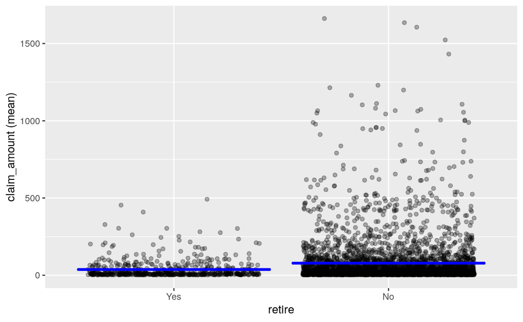

```r
plot(result2, plots = "scatter", custom = FALSE)
```

Clearly describe your null and alternative hypotheses in each case. Provide both graphical and statistical evidence to support your recommendation.

### Question 3

*Have RadySafe Insurance’s efforts to catch fraud been effective?*

At the end of 2007, RadySafe invested heavily to implement fraud detection algorithms in their claims processes. For the year of 2007, they ultimately determined that 9.8% of all claims were fraudulent. RadySafe wants to know if their investment in fraud detection has paid off in 2008.

Do you believe their investments have enabled them to identify fraud significantly better? Please explain your reasoning. Clearly describe your null and alternative hypotheses. For simplicity, you may assume that policy holders are no more, or less, likely to file fraudulent claims in 2008 and that any difference in detection rate can be linked to the new detection algorithms.

H0: the fraud detection rate in 2008 is equal to 9.8% Ha: the fraud detection rate in 2008 is less than 9.8% p value is 0.940. We can not reject the null hypothesis using a significance level of 0.05 and can not conclude the detection their investments have enabled them to identify fraud significantly better.

```r
result3 <- single_prop(
  insurance,
  var = "fraudulent",
  lev = "Yes",
  comp_value = 0.098,
  alternative = "less"
)
summary(result3)
```

```
## Single proportion test (binomial exact)
## Data      : insurance
## Variable  : fraudulent
## Level     : Yes in fraudulent
## Confidence: 0.95
## Null hyp. : the proportion of Yes in fraudulent = 0.098
## Alt. hyp. : the proportion of Yes in fraudulent < 0.098
##
##   prop mean     sd     n n_missing
##  0.105  463 20.358 4,415         0
##
##   diff  ns p.value    0%   95%
##  0.007 463   0.940 0.000 0.113
##
## Signif. codes:  0 '***' 0.001 '**' 0.01 '*' 0.05 '.' 0.1 ' ' 1
```

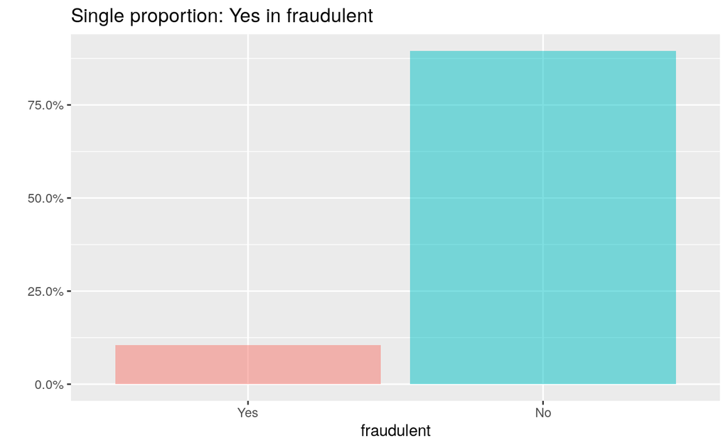

```r
plot(result3, plots = "bar", custom = FALSE)
```

### Question 4

*Are fraudulent claim amounts higher or lower than non-fraudulent claim amounts?*

Clearly describe your null and alternative hypotheses. Provide both graphical and statistical evidence to support your answer.

H0： Average fraudulent claim amounts is equal to non-fraudulent claim amounts. Ha: Average fraudulent claim amounts is not equal to non-fraudulent claim amounts. p value is 0.239. We can not reject the null hypothesis using a significance level of 0.05 and can not conclude fraudulent claim amounts is significantly different from non-fraudulent claim amounts.

```r
result4 <- compare_means(
  insurance,
  var1 = "fraudulent",
  var2 = "claim_amount"
)
summary(result4, show = FALSE)
```

```
## Pairwise mean comparisons (t-test)
## Data      : insurance
## Variables : fraudulent, claim_amount
## Samples   : independent
## Confidence: 0.95
## Adjustment: None
##
##  fraudulent   mean     n      sd    se     me
##         Yes 66.009   463 133.863 6.221 12.225
##          No 73.831 3,952 145.580 2.316  4.540
##
##  Null hyp.  Alt. hyp.             diff   p.value
##  Yes = No   Yes not equal to No   -7.822 0.239
##
## Signif. codes:  0 '***' 0.001 '**' 0.01 '*' 0.05 '.' 0.1 ' ' 1
```

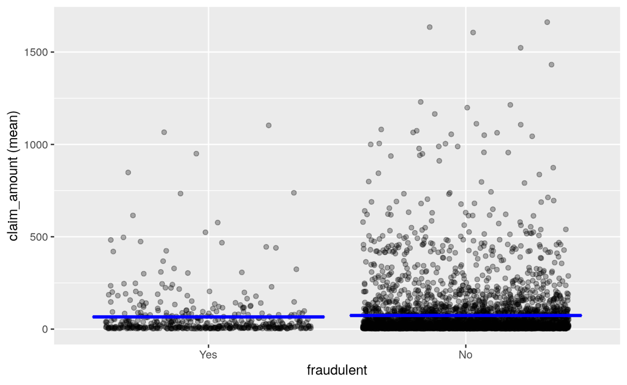

```r
plot(result4, plots = "scatter", custom = FALSE)
```

### Question 5

*Is there a relationship between one’s educational level and one’s likelihood of submitting a fraudulent claim?*

Create a table and plot in the *Data > Pivot* tab to investigate if there is a relationship between education level (`edcat`) and the likelihood of a fraudulent claim. Hint: Try *Dodge* and *Fill* plots. Also try normalizing by Row and Column totals and use conditional formatting (e.g., `Color bar`). What guidance on this question can you offer to RadySafe?

##For education levels under college, the higher the education level, the higher the probability that they make a fraudulent claim. For people who are post-college, their likelihood of conducting a fraudulent claim is slightly lower than the high school graduates. Based on what we learned here, I highly recommend the insurance company charges the highest premium on policyholders with a college degree while charging the lowest premium on policyholders with no high school degree.

```r
result5 <- pivotr(
  insurance,
  cvars = c("edcat", "fraudulent"),
  normalize = "column",
  nr = Inf
)
summary(result5, perc = TRUE)
```

```
## Pivot table
## Data        : insurance
## Categorical : edcat fraudulent
## Normalize by: column
##
##  fraudulent No_high_school High_school Some_college  College Post_college
##         Yes         9.079%     10.197%      11.194%  11.414%      10.164%
##          No        90.921%     89.803%      88.806%  88.586%      89.836%
##       Total       100.000%    100.000%     100.000% 100.000%     100.000%
##     Total
##   10.487%
##   89.513%
##  100.000%
```

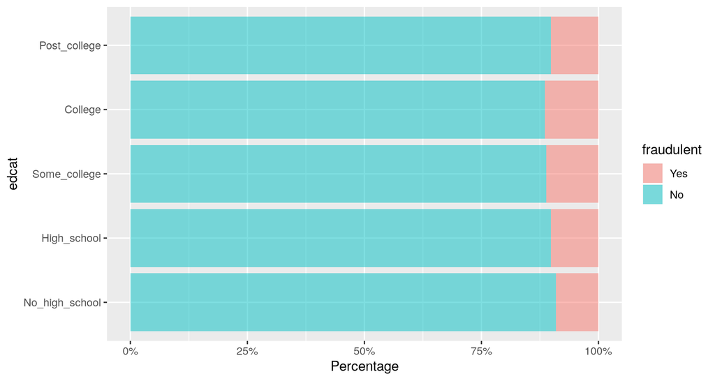

```r
plot(result5, type = "fill", perc = TRUE, flip = TRUE)
```

```r
# dtab(result, format = "color_bar", perc = TRUE) %>% render()
```

Note: We will discuss a statistical test in the next class to evaluate if there are significant differences.

# [3] Case Study

Conduct a complete analysis of the *Shared Social Responsibility* case. Turn in your case at the beginning of class.

If your team would like to volunteer to present your findings in a 10-15 min presentation at the beginning of next session, send me an e-mail by **Tuesday afternoon at 5pm**, to give your team enough time to prepare. If I receive no emails by then, I will accept the first team that emails me.